# Dummy Variables and Probability Models

Author

Statistics for Business

Published

November 18, 2025

# 1 Introduction

In this lesson, we extend our regression toolkit to handle two important scenarios:

1. **Dummy Variable Models**: How to include categorical predictors in regression
2. **Probability Models**: How to model binary outcomes (0/1, yes/no, success/failure)

Building on our understanding of conditional expectation and OLS from Week 2, we’ll see how these techniques naturally extend to categorical variables and binary outcomes.

# 2 Part 1: Dummy Variable Models

## 2.1 Motivation: Categorical Predictors

So far, we’ve worked with continuous predictors like education and wage. But many real-world variables are categorical:

- Gender (Male/Female)
- Region (North/South/East/West)
- Product type (A/B/C)
- Treatment group (Control/Treatment)

**Question**: How do we include these in a regression model?

**Answer**: We encode categorical variables as **dummy variables** (also called indicator variables or binary variables).

## 2.2 Mathematical Foundation of Dummy Variables

### 2.2.1 Binary Categories

For a binary categorical variable (two categories), we create a dummy variable:

$$D_i = \begin{cases}
1 & \text{if observation } i \text{ belongs to category 1} \\
0 & \text{if observation } i \text{ belongs to category 0 (reference)}
\end{cases}$$

The regression model becomes:

$$Y_i = \beta_0 + \beta_1 D_i + \varepsilon_i$$

**Interpretation:**

- When $D_i = 0$ (reference group): $E(Y_i|D_i=0) = \beta_0$
- When $D_i = 1$ (treatment group): $E(Y_i|D_i=1) = \beta_0 + \beta_1$
- Therefore: $\beta_1 = E(Y|D=1) - E(Y|D=0)$ (the mean difference between groups)

### 2.2.2 Example: Car Fuel Efficiency

Let’s use the `mtcars` dataset to predict miles per gallon (MPG) based on transmission type.

```r
# Load and prepare the mtcars dataset
data(mtcars)

# Create a copy and add descriptive labels
cars <- mtcars %>%
  mutate(
    transmission = factor(am, levels = c(0, 1),
                         labels = c("Automatic", "Manual")),
    transmission_dummy = am  # Keep numeric version for clarity
  )

# Display first few observations
head(cars %>% select(mpg, transmission, transmission_dummy, wt, hp), 10) %>%
  kable(caption = "Car Dataset: MPG by Transmission Type",
        col.names = c("MPG", "Transmission", "Dummy (D)", "Weight", "Horsepower"),
        digits = 2) %>%
  kable_styling(bootstrap_options = c("striped", "hover"))
```

Car Dataset: MPG by Transmission Type

|  | MPG | Transmission | Dummy (D) | Weight | Horsepower |
| --- | --- | --- | --- | --- | --- |
| Mazda RX4 | 21.0 | Manual | 1 | 2.62 | 110 |
| Mazda RX4 Wag | 21.0 | Manual | 1 | 2.88 | 110 |
| Datsun 710 | 22.8 | Manual | 1 | 2.32 | 93 |
| Hornet 4 Drive | 21.4 | Automatic | 0 | 3.21 | 110 |
| Hornet Sportabout | 18.7 | Automatic | 0 | 3.44 | 175 |
| Valiant | 18.1 | Automatic | 0 | 3.46 | 105 |
| Duster 360 | 14.3 | Automatic | 0 | 3.57 | 245 |
| Merc 240D | 24.4 | Automatic | 0 | 3.19 | 62 |
| Merc 230 | 22.8 | Automatic | 0 | 3.15 | 95 |
| Merc 280 | 19.2 | Automatic | 0 | 3.44 | 123 |

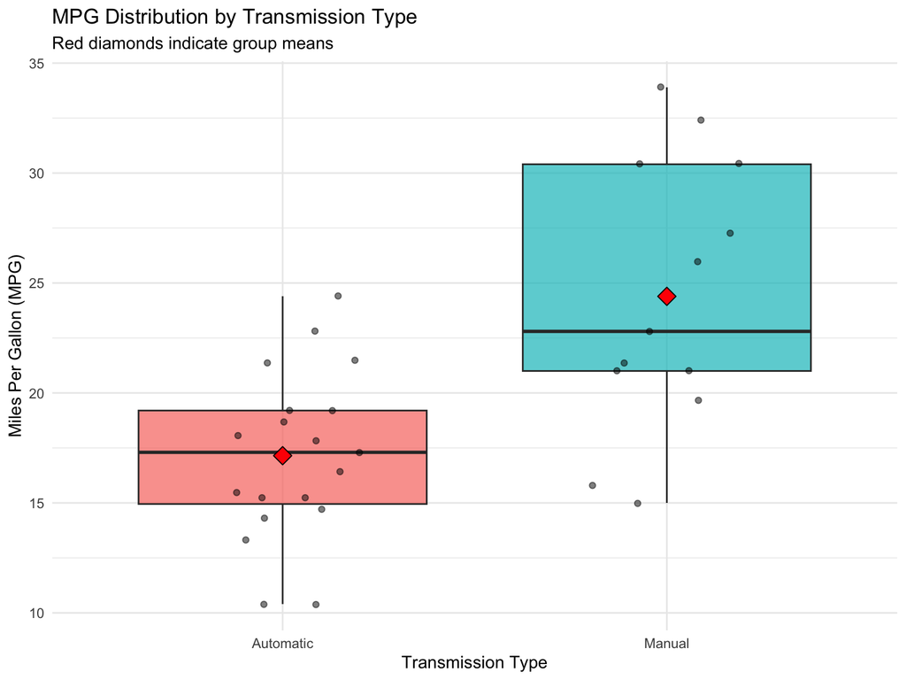

```r
# Visualize MPG by transmission type
ggplot(cars, aes(x = transmission, y = mpg, fill = transmission)) +
  geom_boxplot(alpha = 0.7) +
  geom_jitter(width = 0.2, alpha = 0.5) +
  stat_summary(fun = mean, geom = "point", shape = 23, size = 4,
               fill = "red", color = "black") +
  labs(title = "MPG Distribution by Transmission Type",
       subtitle = "Red diamonds indicate group means",
       x = "Transmission Type",
       y = "Miles Per Gallon (MPG)") +
  theme_minimal() +
  theme(legend.position = "none")
```

### 2.2.3 Estimating the Dummy Variable Model

Let’s estimate the model: $\text{MPG}_i = \beta_0 + \beta_1 \cdot D_i + \varepsilon_i$

```r
# Fit the model
model_dummy <- lm(mpg ~ transmission_dummy, data = cars)
summary(model_dummy)
```

```
Call:
lm(formula = mpg ~ transmission_dummy, data = cars)

Residuals:
    Min      1Q  Median      3Q     Max
-9.3923 -3.0923 -0.2974  3.2439  9.5077

Coefficients:
                   Estimate Std. Error t value Pr(>|t|)
(Intercept)          17.147      1.125  15.247 1.13e-15 ***
transmission_dummy    7.245      1.764   4.106 0.000285 ***
---
Signif. codes:  0 '***' 0.001 '**' 0.01 '*' 0.05 '.' 0.1 ' ' 1

Residual standard error: 4.902 on 30 degrees of freedom
Multiple R-squared:  0.3598,    Adjusted R-squared:  0.3385
F-statistic: 16.86 on 1 and 30 DF,  p-value: 0.000285
```

The estimated model is: $\widehat{\text{MPG}} = 17.147 + 7.245 \times D$

### 2.2.4 Verifying the Interpretation

Let’s verify that $\beta_1$ equals the difference in group means:

```r
# Calculate group means
group_means <- cars %>%
  group_by(transmission) %>%
  summarise(
    n = n(),
    mean_mpg = mean(mpg),
    sd_mpg = sd(mpg)
  )

kable(group_means,
      caption = "Mean MPG by Transmission Type",
      digits = 3,
      col.names = c("Transmission", "n", "Mean MPG", "SD MPG")) %>%
  kable_styling(bootstrap_options = c("striped", "hover"), full_width = FALSE)
```

Mean MPG by Transmission Type

| Transmission | n | Mean MPG | SD MPG |
| --- | --- | --- | --- |
| Automatic | 19 | 17.147 | 3.834 |
| Manual | 13 | 24.392 | 6.167 |

The coefficient $\beta_1 = 7.245$ equals the difference in group means: 7.245. This shows that the dummy variable coefficient is simply the difference between group means, connecting regression to the two-sample t-test.

## 2.3 Multiple Categories: The k-1 Rule

When a categorical variable has $k$ categories, we create $k-1$ dummy variables, leaving one category as the **reference group**.

**Why k-1 and not k?** To avoid the **dummy variable trap** (perfect multicollinearity).

### 2.3.1 Mathematical Proof of the Dummy Variable Trap

Suppose we have 3 categories and create 3 dummies: $D_1$, $D_2$, $D_3$. For every observation, exactly one dummy equals 1:

$$D_1 + D_2 + D_3 = 1$$

If we include all three in a regression with an intercept, we have:

$$Y = \beta_0 \cdot 1 + \beta_1 D_1 + \beta_2 D_2 + \beta_3 D_3 + \varepsilon$$

Since the intercept column (all 1’s) equals $D_1 + D_2 + D_3$, the design matrix has linearly dependent columns. The matrix $X'X$ is singular and cannot be inverted, making OLS estimation impossible.

**Solution**: Use k-1 dummies. One category becomes the reference (baseline), and coefficients represent differences from that baseline.

### 2.3.2 Example: Cylinders in Cars

Let’s model MPG using the number of cylinders (4, 6, or 8).

```r
# Create dummy variables for cylinders (using 4 cylinders as reference)
cars <- cars %>%
  mutate(
    cyl_factor = factor(cyl),
    cyl_6 = ifelse(cyl == 6, 1, 0),
    cyl_8 = ifelse(cyl == 8, 1, 0)
  )

# Fit model with k-1 dummies
model_cyl <- lm(mpg ~ cyl_6 + cyl_8, data = cars)
summary(model_cyl)
```

```
Call:
lm(formula = mpg ~ cyl_6 + cyl_8, data = cars)

Residuals:
    Min      1Q  Median      3Q     Max
-5.2636 -1.8357  0.0286  1.3893  7.2364

Coefficients:
            Estimate Std. Error t value Pr(>|t|)
(Intercept)  26.6636     0.9718  27.437  < 2e-16 ***
cyl_6        -6.9208     1.5583  -4.441 0.000119 ***
cyl_8       -11.5636     1.2986  -8.905 8.57e-10 ***
---
Signif. codes:  0 '***' 0.001 '**' 0.01 '*' 0.05 '.' 0.1 ' ' 1

Residual standard error: 3.223 on 29 degrees of freedom
Multiple R-squared:  0.7325,    Adjusted R-squared:  0.714
F-statistic:  39.7 on 2 and 29 DF,  p-value: 4.979e-09
```

**Interpretation**:

- $\beta_0 = 26.66$: Mean MPG for 4-cylinder cars (reference)
- $\beta_1 = -6.92$: 6-cylinder cars get -6.92 fewer MPG than 4-cylinder
- $\beta_2 = -11.56$: 8-cylinder cars get -11.56 fewer MPG than 4-cylinder

```r
# Verify by comparing with group means
cyl_means <- cars %>%
  group_by(cyl) %>%
  summarise(mean_mpg = mean(mpg), n = n())

kable(cyl_means,
      caption = "Mean MPG by Number of Cylinders",
      col.names = c("Cylinders", "Mean MPG", "n"),
      digits = 2) %>%
  kable_styling(bootstrap_options = c("striped", "hover"), full_width = FALSE)
```

Mean MPG by Number of Cylinders

| Cylinders | Mean MPG | n |
| --- | --- | --- |
| 4 | 26.66 | 11 |
| 6 | 19.74 | 7 |
| 8 | 15.10 | 14 |

The coefficients match the differences from the reference category (4 cylinders).

## 2.4 Interaction Terms

Interaction terms allow the effect of one variable to depend on the value of another variable.

### 2.4.1 Dummy × Continuous Interactions

Suppose we want to model how the relationship between weight and MPG differs by transmission type:

$$\text{MPG}_i = \beta_0 + \beta_1 \cdot \text{Weight}_i + \beta_2 \cdot D_i + \beta_3 \cdot (\text{Weight}_i \times D_i) + \varepsilon_i$$

**Interpretation:**

For automatic transmission ($D=0$):
$$E(\text{MPG}|\text{Weight}, D=0) = \beta_0 + \beta_1 \cdot \text{Weight}$$

For manual transmission ($D=1$):
$$E(\text{MPG}|\text{Weight}, D=1) = (\beta_0 + \beta_2) + (\beta_1 + \beta_3) \cdot \text{Weight}$$

So:

- $\beta_2$: Difference in intercept between manual and automatic
- $\beta_3$: Difference in slope (how much steeper/flatter the relationship is for manual)

```r
# Fit model with interaction
model_interact <- lm(mpg ~ wt + transmission_dummy + wt:transmission_dummy, data = cars)
summary(model_interact)
```

```
Call:
lm(formula = mpg ~ wt + transmission_dummy + wt:transmission_dummy,
    data = cars)

Residuals:
    Min      1Q  Median      3Q     Max
-3.6004 -1.5446 -0.5325  0.9012  6.0909

Coefficients:
                      Estimate Std. Error t value Pr(>|t|)
(Intercept)            31.4161     3.0201  10.402 4.00e-11 ***
wt                     -3.7859     0.7856  -4.819 4.55e-05 ***
transmission_dummy     14.8784     4.2640   3.489  0.00162 **
wt:transmission_dummy  -5.2984     1.4447  -3.667  0.00102 **
---
Signif. codes:  0 '***' 0.001 '**' 0.01 '*' 0.05 '.' 0.1 ' ' 1

Residual standard error: 2.591 on 28 degrees of freedom
Multiple R-squared:  0.833, Adjusted R-squared:  0.8151
F-statistic: 46.57 on 3 and 28 DF,  p-value: 5.209e-11
```

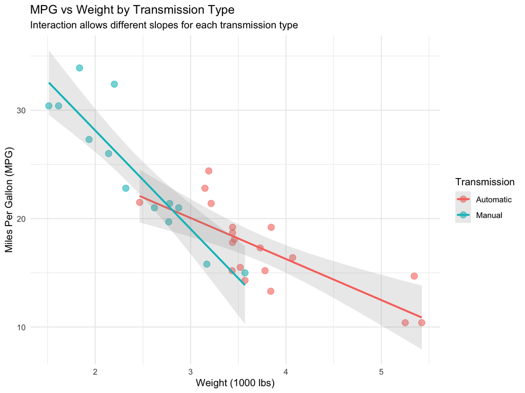

```r
# Visualize the interaction
ggplot(cars, aes(x = wt, y = mpg, color = transmission)) +
  geom_point(size = 3, alpha = 0.6) +
  geom_smooth(method = "lm", se = TRUE, alpha = 0.2) +
  labs(title = "MPG vs Weight by Transmission Type",
       subtitle = "Interaction allows different slopes for each transmission type",
       x = "Weight (1000 lbs)",
       y = "Miles Per Gallon (MPG)",
       color = "Transmission") +
  theme_minimal()
```

The interaction term ($\beta_3 = -5.3$) is negative, indicating that the negative effect of weight on MPG is more severe for manual transmission cars.

### 2.4.2 Dummy × Dummy Interactions

When we have two categorical variables, their interaction captures combined effects:

$$Y_i = \beta_0 + \beta_1 D_{1i} + \beta_2 D_{2i} + \beta_3 (D_{1i} \times D_{2i}) + \varepsilon_i$$

This creates 4 distinct groups:

- $D_1=0, D_2=0$ (reference): $E(Y) = \beta_0$
- $D_1=1, D_2=0$: $E(Y) = \beta_0 + \beta_1$
- $D_1=0, D_2=1$: $E(Y) = \beta_0 + \beta_2$
- $D_1=1, D_2=1$: $E(Y) = \beta_0 + \beta_1 + \beta_2 + \beta_3$

The interaction $\beta_3$ captures whether the combined effect differs from the sum of individual effects.

```r
# Create a binary variable for high performance (hp > median)
cars <- cars %>%
  mutate(high_hp = ifelse(hp > median(hp), 1, 0))

# Fit model with dummy × dummy interaction
model_dd_interact <- lm(mpg ~ transmission_dummy + high_hp +
                         transmission_dummy:high_hp, data = cars)
summary(model_dd_interact)
```

```
Call:
lm(formula = mpg ~ transmission_dummy + high_hp + transmission_dummy:high_hp,
    data = cars)

Residuals:
   Min     1Q Median     3Q    Max
-5.660 -2.036  0.150  2.404  7.240

Coefficients:
                           Estimate Std. Error t value Pr(>|t|)
(Intercept)                  20.743      1.345  15.418 3.28e-15 ***
transmission_dummy            5.917      1.754   3.373  0.00219 **
high_hp                      -5.693      1.693  -3.363  0.00225 **
transmission_dummy:high_hp   -4.134      2.891  -1.430  0.16378
---
Signif. codes:  0 '***' 0.001 '**' 0.01 '*' 0.05 '.' 0.1 ' ' 1

Residual standard error: 3.56 on 28 degrees of freedom
Multiple R-squared:  0.6849,    Adjusted R-squared:  0.6512
F-statistic: 20.29 on 3 and 28 DF,  p-value: 3.458e-07
```

```r
# Create means table for all four groups
interaction_means <- cars %>%
  group_by(transmission, high_hp_cat = ifelse(high_hp == 1, "High HP", "Low HP")) %>%
  summarise(mean_mpg = mean(mpg), n = n(), .groups = "drop")

kable(interaction_means,
      caption = "Mean MPG by Transmission Type and Horsepower",
      col.names = c("Transmission", "Horsepower", "Mean MPG", "n"),
      digits = 2) %>%
  kable_styling(bootstrap_options = c("striped", "hover"), full_width = FALSE)
```

Mean MPG by Transmission Type and Horsepower

| Transmission | Horsepower | Mean MPG | n |
| --- | --- | --- | --- |
| Automatic | High HP | 15.05 | 12 |
| Automatic | Low HP | 20.74 | 7 |
| Manual | High HP | 16.83 | 3 |
| Manual | Low HP | 26.66 | 10 |

# 3 Part 2: Probability Models for Binary Outcomes

## 3.1 Motivation: Predicting Binary Outcomes

So far, our outcome $Y$ has been continuous (wage, MPG). But many important outcomes are binary:

- Loan default (Yes/No)
- Customer churn (Stay/Leave)
- Product purchase (Buy/Don’t Buy)
- Disease diagnosis (Positive/Negative)

**Challenge**: Standard OLS regression can predict values outside [0,1], which don’t make sense as probabilities.

## 3.2 Linear Probability Model (LPM)

### 3.2.1 Mathematical Formulation

For a binary outcome $Y_i \in \{0, 1\}$, we model the probability:

$$P(Y_i = 1 | X_i) = \beta_0 + \beta_1 X_i$$

Despite $Y$ being binary, we can still use OLS because:

$$E(Y_i | X_i) = 1 \cdot P(Y_i=1|X_i) + 0 \cdot P(Y_i=0|X_i) = P(Y_i=1|X_i)$$

So the conditional expectation equals the probability of success!

### 3.2.2 Coefficient Interpretation

In LPM, $\beta_1$ represents the **marginal effect**: the change in probability for a one-unit increase in $X$.

$$\frac{\partial P(Y=1|X)}{\partial X} = \beta_1$$

This is much simpler to interpret than logistic regression coefficients.

### 3.2.3 Limitations of LPM

Despite its simplicity, LPM has serious problems:

1. **Predictions outside [0,1]**: Nothing constrains predictions to valid probabilities
2. **Heteroskedasticity**: $\text{Var}(\varepsilon_i|X_i) = P(Y=1|X_i)[1-P(Y=1|X_i)]$ varies with $X$
3. **Linear probability assumption**: Assumes constant marginal effects across all $X$ values

### 3.2.4 Analytical Derivation of Heteroskedasticity

For binary $Y_i \in \{0, 1\}$:

$$\text{Var}(Y_i | X_i) = E(Y_i^2|X_i) - [E(Y_i|X_i)]^2$$

Since $Y_i^2 = Y_i$ for binary variables:

$$\text{Var}(Y_i | X_i) = E(Y_i|X_i) - [E(Y_i|X_i)]^2 = p_i - p_i^2 = p_i(1-p_i)$$

where $p_i = P(Y_i=1|X_i)$. Since $p_i$ changes with $X_i$, the variance is not constant—this is heteroskedasticity.

## 3.3 Logistic Regression

### 3.3.1 Motivation: Need for Bounded Predictions

We need a model that:

- Maps any real number to [0,1]
- Has an S-shaped curve (probabilities should change slowly at extremes)
- Is flexible and mathematically tractable

The **logistic function** provides this:

$$P(Y=1|X) = \frac{e^{\beta_0 + \beta_1 X}}{1 + e^{\beta_0 + \beta_1 X}} = \frac{1}{1 + e^{-(\beta_0 + \beta_1 X)}}$$

### 3.3.2 The Logit Transformation

Instead of modeling probability directly, we model the **log-odds** (logit):

$$\text{logit}(p) = \log\left(\frac{p}{1-p}\right) = \beta_0 + \beta_1 X$$

Where $\frac{p}{1-p}$ is the **odds**. Taking the exponential of both sides:

$$\frac{p}{1-p} = e^{\beta_0 + \beta_1 X}$$

Solving for $p$:

$$p = \frac{e^{\beta_0 + \beta_1 X}}{1 + e^{\beta_0 + \beta_1 X}}$$

This guarantees $0 < p < 1$ for any value of $X$.

### 3.3.3 Understanding Odds and Log-Odds

**Odds**: The ratio of success probability to failure probability

$$\text{Odds} = \frac{P(Y=1)}{P(Y=0)} = \frac{p}{1-p}$$

**Examples**:

- If $p = 0.5$: Odds = 1 (even odds)
- If $p = 0.75$: Odds = 3 (3-to-1 odds in favor)
- If $p = 0.9$: Odds = 9 (9-to-1 odds in favor)

**Log-Odds (Logit)**: Taking the log makes the relationship linear:

$$\log(\text{Odds}) = \log\left(\frac{p}{1-p}\right) = \beta_0 + \beta_1 X$$

### 3.3.4 Maximum Likelihood Estimation

Unlike OLS, logistic regression has no closed-form solution. We use **Maximum Likelihood Estimation (MLE)**.

#### 3.3.4.1 The Likelihood Function

For observation $i$, the probability of observing $Y_i$ is:

$$P(Y_i | X_i) = p_i^{Y_i}(1-p_i)^{1-Y_i}$$

This equals $p_i$ when $Y_i=1$ and $(1-p_i)$ when $Y_i=0$.

The likelihood for all observations (assuming independence):

$$L(\beta) = \prod_{i=1}^{n} p_i^{Y_i}(1-p_i)^{1-Y_i}$$

where $p_i = \frac{e^{\beta_0 + \beta_1 X_i}}{1 + e^{\beta_0 + \beta_1 X_i}}$

#### 3.3.4.2 Log-Likelihood

We maximize the log-likelihood (easier mathematically):

$$\ell(\beta) = \sum_{i=1}^{n} \left[Y_i \log(p_i) + (1-Y_i)\log(1-p_i)\right]$$

Substituting the logistic function:

$$\ell(\beta) = \sum_{i=1}^{n} \left[Y_i(\beta_0 + \beta_1 X_i) - \log(1 + e^{\beta_0 + \beta_1 X_i})\right]$$

#### 3.3.4.3 Score Equations

Taking derivatives with respect to $\beta$ and setting to zero:

$$\frac{\partial \ell}{\partial \beta_0} = \sum_{i=1}^{n} (Y_i - p_i) = 0$$

$$\frac{\partial \ell}{\partial \beta_1} = \sum_{i=1}^{n} X_i(Y_i - p_i) = 0$$

These have no closed-form solution, so we use iterative methods (Newton-Raphson) to find $\hat{\beta}$ that maximizes $\ell(\beta)$.

### 3.3.5 Coefficient Interpretation

Logistic regression coefficients can be interpreted in four complementary ways. Understanding all four provides complete insight into the model.

#### 3.3.5.1 Interpretation 1: Log-Odds (Logit)

The most direct interpretation is on the **log-odds scale**:

$$\log\left(\frac{p}{1-p}\right) = \beta_0 + \beta_1 X$$

A one-unit increase in $X$ changes the log-odds by $\beta_1$.

**Note**: Log-odds can take any value from $-\infty$ to $+\infty$, making this a linear relationship.

#### 3.3.5.2 Interpretation 2: Odds

The **odds** of an event is the ratio of success probability to failure probability:

$$\text{Odds} = \frac{p}{1-p} = e^{\beta_0 + \beta_1 X}$$

**Important distinction**: This is **odds** (a single value), not odds ratio (which compares two odds).

- If $p = 0.5$, odds = 1 (even odds)
- If $p = 0.75$, odds = 3 (3-to-1 in favor)
- If $p = 0.9$, odds = 9 (9-to-1 in favor)

Odds range from 0 to $\infty$.

#### 3.3.5.3 Interpretation 3: Odds Ratio

The **odds ratio** compares odds at two different values of $X$:

$$\text{Odds Ratio} = \frac{\text{Odds at } X+1}{\text{Odds at } X} = \frac{e^{\beta_0 + \beta_1(X+1)}}{e^{\beta_0 + \beta_1 X}} = e^{\beta_1}$$

This tells us how the odds **multiply** for a one-unit increase in $X$.

**Example**: If $\beta_1 = 0.693$, then $e^{0.693} \approx 2$. The odds double (multiply by 2) for each unit increase in $X$.

**Key point**: The odds ratio is **constant** across all values of $X$ in logistic regression, unlike marginal effects which vary.

#### 3.3.5.4 Interpretation 4: Marginal Effects

The **marginal effect** measures the change in probability for a one-unit increase in $X$:

$$\frac{\partial P(Y=1|X)}{\partial X} = \beta_1 \cdot p(1-p)$$

**Key insight**: The marginal effect **depends on the current probability level** $p$:

- Largest when $p=0.5$ (maximum of $\beta_1/4$)
- Approaches zero at probability extremes ($p \to 0$ or $p \to 1$)
- This creates the S-shaped logistic curve

We typically report:

- **Average Marginal Effect (AME)**: Average $\beta_1 \cdot p_i(1-p_i)$ across all observations
- **Marginal Effect at Means (MEM)**: Evaluate at $p = P(Y=1|\bar{X})$

### 3.3.6 Simple Numerical Example: All Four Interpretations

Let’s work through a concrete example to understand each interpretation.

**Setup**: Suppose we have a logistic model for credit card default:

$$\log\left(\frac{p}{1-p}\right) = -10 + 0.005 \times \text{Balance}$$

So $\beta_0 = -10$ and $\beta_1 = 0.005$.

#### 3.3.6.1 Example 1: Customer with Balance = $1,000

**Step 1: Calculate Log-Odds**
$$\log\left(\frac{p}{1-p}\right) = -10 + 0.005(1000) = -10 + 5 = -5$$

**Step 2: Calculate Odds**
$$\text{Odds} = e^{-5} = 0.0067$$

This means the odds are approximately **149-to-1 against defaulting** (since 1/0.0067 ≈ 149). In other words, for every 1 customer who defaults, about 149 customers do not default.

**Step 3: Calculate Probability**
$$p = \frac{e^{-5}}{1 + e^{-5}} = \frac{0.0067}{1.0067} = 0.0066$$

So there’s a 0.66% chance of default at this balance.

**Step 4: Calculate Marginal Effect**
$$\text{ME} = 0.005 \times 0.0066 \times (1-0.0066) = 0.005 \times 0.0066 \times 0.9934 = 0.0000328$$

A $1 increase in balance increases default probability by 0.00328%.

#### 3.3.6.2 Example 2: Customer with Balance = $2,000

**Step 1: Calculate Log-Odds**
$$\log\left(\frac{p}{1-p}\right) = -10 + 0.005(2000) = -10 + 10 = 0$$

**Step 2: Calculate Odds**
$$\text{Odds} = e^{0} = 1$$

The odds are exactly 1-to-1 (even odds).

**Step 3: Calculate Probability**
$$p = \frac{e^{0}}{1 + e^{0}} = \frac{1}{2} = 0.50$$

There’s a 50% chance of default at this balance.

**Step 4: Calculate Marginal Effect**
$$\text{ME} = 0.005 \times 0.50 \times (1-0.50) = 0.005 \times 0.50 \times 0.50 = 0.00125$$

A $1 increase in balance increases default probability by 0.125%.

#### 3.3.6.3 Example 3: Odds Ratio for $1,000 Increase

Compare Customer with Balance = $1,000 vs $2,000:

**Odds Ratio**:
$$\text{OR} = e^{\beta_1 \times 1000} = e^{0.005 \times 1000} = e^{5} = 148.4$$

The odds of default multiply by 148.4 when balance increases from $1,000 to $2,000.

**Verification**:

- Odds at $1,000: 0.0067
- Odds at $2,000: 1.0
- Ratio: $1.0 / 0.0067 = 149.3$ ✓ (slight rounding difference).

### 3.3.7 Comparison Table: All Four Measures

```r
# Create a comprehensive comparison table
interpretation_table <- data.frame(
  Measure = c("Log-Odds (Logit)", "Odds", "Odds Ratio", "Marginal Effect"),
  Formula = c(
    "log(p/(1-p)) = β₀ + β₁X",
    "p/(1-p) = exp(β₀ + β₁X)",
    "exp(β₁) for 1-unit ↑ in X",
    "β₁ × p × (1-p)"
  ),
  Range = c(
    "(-∞, +∞)",
    "(0, +∞)",
    "(0, +∞)",
    "(-∞, +∞)"
  ),
  Interpretation = c(
    "Linear effect on log-odds scale",
    "Ratio of success to failure probability",
    "How odds multiply for 1-unit increase in X",
    "Change in probability for 1-unit increase in X"
  ),
  Constant_Across_X = c(
    "Slope β₁ is constant",
    "No - odds change with X",
    "Yes - always exp(β₁)",
    "No - varies with probability level"
  ),
  Example_Value = c(
    "At Balance=$1,000: -5",
    "At Balance=$1,000: 0.0067",
    "For $1,000 increase: 148.4",
    "At Balance=$1,000: 0.0000328"
  )
)

kable(interpretation_table,
      caption = "Four Ways to Interpret Logistic Regression Coefficients",
      col.names = c("Measure", "Formula", "Range", "Interpretation",
                    "Constant Across X?", "Example (β₁=0.005)")) %>%
  kable_styling(bootstrap_options = c("striped", "hover"),
                full_width = TRUE, font_size = 12)
```

Four Ways to Interpret Logistic Regression Coefficients

| Measure | Formula | Range | Interpretation | Constant Across X? | Example (β₁=0.005) |
| --- | --- | --- | --- | --- | --- |
| Log-Odds (Logit) | log(p/(1-p)) = β₀ + β₁X | (-∞, +∞) | Linear effect on log-odds scale | Slope β₁ is constant | At Balance=$1,000: -5 |
| Odds | p/(1-p) = exp(β₀ + β₁X) | (0, +∞) | Ratio of success to failure probability | No - odds change with X | At Balance=$1,000: 0.0067 |
| Odds Ratio | exp(β₁) for 1-unit ↑ in X | (0, +∞) | How odds multiply for 1-unit increase in X | Yes - always exp(β₁) | For $1,000 increase: 148.4 |
| Marginal Effect | β₁ × p × (1-p) | (-∞, +∞) | Change in probability for 1-unit increase in X | No - varies with probability level | At Balance=$1,000: 0.0000328 |

**Key Takeaways**:

1. **Log-odds** provides the direct linear relationship
2. **Odds** shows the ratio of success to failure at a given X
3. **Odds ratio** (exp(β₁)) is the **multiplicative change** in odds - it’s constant across all X values
4. **Marginal effect** is most intuitive (change in probability) but varies with X

For **reporting results**: - Academic papers often report odds ratios (constant and easy to compare) - Policy analysis often reports marginal effects (intuitive as probability changes) - Always clarify which interpretation you’re using to avoid confusion!

## 3.4 Comparison: LPM vs Logistic Regression

Let’s compare these models using credit card default data.

### 3.4.1 Example: Credit Card Default

```r
# Load the Default dataset from ISLR2
data("Default")

# Examine the data
head(Default, 10) %>%
  kable(caption = "Credit Card Default Dataset",
        col.names = c("Default Status", "Student Status", "Balance", "Income"),
        digits = 0) %>%
  kable_styling(bootstrap_options = c("striped", "hover"))
```

Credit Card Default Dataset

| Default Status | Student Status | Balance | Income |
| --- | --- | --- | --- |
| No | No | 730 | 44362 |
| No | Yes | 817 | 12106 |
| No | No | 1074 | 31767 |
| No | No | 529 | 35704 |
| No | No | 786 | 38463 |
| No | Yes | 920 | 7492 |
| No | No | 826 | 24905 |
| No | Yes | 809 | 17600 |
| No | No | 1161 | 37469 |
| No | No | 0 | 29275 |

```r
# Summary statistics
summary(Default)
```

```
 default    student       balance           income
 No :9667   No :7056   Min.   :   0.0   Min.   :  772
 Yes: 333   Yes:2944   1st Qu.: 481.7   1st Qu.:21340
                       Median : 823.6   Median :34553
                       Mean   : 835.4   Mean   :33517
                       3rd Qu.:1166.3   3rd Qu.:43808
                       Max.   :2654.3   Max.   :73554
```

```r
# Create binary outcome
Default <- Default %>%
  mutate(
    default_binary = ifelse(default == "Yes", 1, 0),
    student_binary = ifelse(student == "Yes", 1, 0)
  )
```

### 3.4.2 Fit Both Models

```r
# Linear Probability Model
lpm_model <- lm(default_binary ~ balance, data = Default)

# Logistic Regression
logit_model <- glm(default_binary ~ balance, data = Default, family = binomial)

# Display results side by side
lpm_summary <- summary(lpm_model)
logit_summary <- summary(logit_model)

# Extract coefficients
lpm_coef <- coef(lpm_model)
logit_coef <- coef(logit_model)

# Create comparison table
comparison_table <- data.frame(
  Model = c("LPM", "Logistic"),
  Intercept = c(lpm_coef[1], logit_coef[1]),
  Slope = c(lpm_coef[2], logit_coef[2])
)

kable(comparison_table,
      caption = "Model Comparison: LPM vs Logistic Regression",
      digits = 6) %>%
  kable_styling(bootstrap_options = c("striped", "hover"), full_width = FALSE)
```

Model Comparison: LPM vs Logistic Regression

| Model | Intercept | Slope |
| --- | --- | --- |
| LPM | -0.075192 | 0.000130 |
| Logistic | -10.651331 | 0.005499 |

**Note**: The coefficients are not directly comparable because:

- LPM: $\beta_1$ is the marginal effect on probability
- Logistic: $\beta_1$ is the effect on log-odds

### 3.4.3 Visualize Predictions

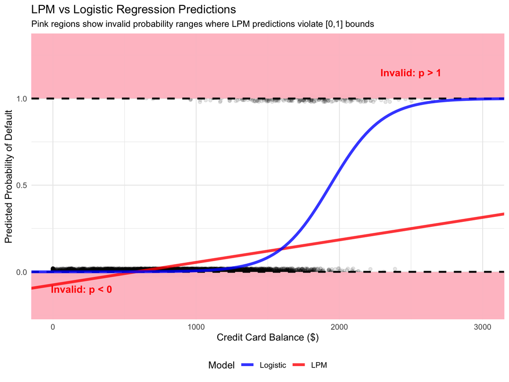

```r
# Create prediction grid - extend range to show boundary violations
balance_grid <- data.frame(balance = seq(-500, 3500, length.out = 150))

# Get predictions from both models
balance_grid$lpm_pred <- predict(lpm_model, newdata = balance_grid)
balance_grid$logit_pred <- predict(logit_model, newdata = balance_grid, type = "response")

# Identify where LPM violates boundaries
balance_grid$lpm_violation <- ifelse(balance_grid$lpm_pred < 0 | balance_grid$lpm_pred > 1,
                                     "Violation", "Valid")

# Plot comparison
ggplot(Default, aes(x = balance, y = default_binary)) +
  geom_point(alpha = 0.1, position = position_jitter(height = 0.02)) +
  # Add shaded regions for invalid probabilities
  geom_rect(aes(xmin = -500, xmax = 3500, ymin = -Inf, ymax = 0),
            fill = "pink", alpha = 0.3) +
  geom_rect(aes(xmin = -500, xmax = 3500, ymin = 1, ymax = Inf),
            fill = "pink", alpha = 0.3) +
  # Add boundary lines
  geom_hline(yintercept = c(0, 1), linetype = "dashed", color = "black", size = 1) +
  # Add model predictions
  geom_line(data = balance_grid, aes(y = lpm_pred, color = "LPM"),
            size = 1.5, alpha = 0.8) +
  geom_line(data = balance_grid, aes(y = logit_pred, color = "Logistic"),
            size = 1.5, alpha = 0.8) +
  # Add text annotations
  annotate("text", x = 2500, y = 1.15, label = "Invalid: p > 1",
           size = 4, color = "red", fontface = "bold") +
  annotate("text", x = 200, y = -0.1, label = "Invalid: p < 0",
           size = 4, color = "red", fontface = "bold") +
  labs(title = "LPM vs Logistic Regression Predictions",
       subtitle = "Pink regions show invalid probability ranges where LPM predictions violate [0,1] bounds",
       x = "Credit Card Balance ($)",
       y = "Predicted Probability of Default",
       color = "Model") +
  scale_color_manual(values = c("LPM" = "red", "Logistic" = "blue")) +
  coord_cartesian(ylim = c(-0.2, 1.3), xlim = c(0, 3000)) +
  theme_minimal() +
  theme(legend.position = "bottom",
        plot.subtitle = element_text(size = 10))
```

```r
# Show where LPM predictions are invalid
invalid_regions <- data.frame(
  Region = c("Balance < 0", "Balance > 2500"),
  LPM_Prediction = c(
    paste0(round(predict(lpm_model, newdata = data.frame(balance = 0)), 3)),
    paste0(round(predict(lpm_model, newdata = data.frame(balance = 2500)), 3))
  ),
  Status = c(
    ifelse(predict(lpm_model, newdata = data.frame(balance = 0)) < 0, "Invalid (< 0)", "Valid"),
    ifelse(predict(lpm_model, newdata = data.frame(balance = 2500)) > 1, "Invalid (> 1)", "Valid")
  )
)

kable(invalid_regions,
      caption = "LPM Boundary Violations at Different Balance Levels",
      col.names = c("Balance Range", "LPM Prediction", "Status")) %>%
  kable_styling(bootstrap_options = c("striped", "hover"), full_width = FALSE)
```

LPM Boundary Violations at Different Balance Levels

| Balance Range | LPM Prediction | Status |
| --- | --- | --- |
| Balance < 0 | -0.075 | Invalid (< 0) |
| Balance > 2500 | 0.249 | Valid |

### 3.4.4 Calculate Marginal Effects for Logistic

```r
# Function to calculate marginal effect
calc_marginal_effect <- function(beta, p) {
  return(beta * p * (1 - p))
}

# Get fitted probabilities
Default$fitted_prob <- predict(logit_model, type = "response")

# Calculate marginal effect for each observation
Default$marginal_effect <- calc_marginal_effect(
  logit_coef[2],
  Default$fitted_prob
)

# Average Marginal Effect (AME)
ame <- mean(Default$marginal_effect)

# Marginal Effect at Means (MEM)
mean_balance <- mean(Default$balance)
mean_prob <- predict(logit_model,
                     newdata = data.frame(balance = mean_balance),
                     type = "response")
mem <- calc_marginal_effect(logit_coef[2], mean_prob)

# Create summary table
me_summary <- data.frame(
  Measure = c("LPM Coefficient", "Average Marginal Effect (AME)",
              "Marginal Effect at Means (MEM)"),
  Value = c(lpm_coef[2], ame, mem),
  Interpretation = c(
    "Change in probability per $1 increase in balance",
    "Average change in probability across all observations",
    "Change in probability at mean balance"
  )
)

kable(me_summary,
      caption = "Marginal Effects Comparison",
      digits = 6,
      col.names = c("Measure", "Value", "Interpretation")) %>%
  kable_styling(bootstrap_options = c("striped", "hover"))
```

Marginal Effects Comparison

| Measure | Value | Interpretation |
| --- | --- | --- |
| LPM Coefficient | 0.000130 | Change in probability per $1 increase in balance |
| Average Marginal Effect (AME) | 0.000119 | Average change in probability across all observations |
| Marginal Effect at Means (MEM) | 0.000013 | Change in probability at mean balance |

The LPM coefficient (1.3^{-4}) is close to the AME (1.19^{-4}), showing that for many practical purposes, LPM provides a reasonable approximation to average marginal effects.

#### 3.4.4.1 Understanding AME vs MEM: Detailed Calculation

Let’s examine how these marginal effects are calculated in detail.

**Formula for marginal effect in logistic regression**:

$$\frac{\partial P(Y=1|X)}{\partial X} = \beta_1 \cdot P(Y=1|X) \cdot [1 - P(Y=1|X)] = \beta_1 \cdot p \cdot (1-p)$$

```r
# Show calculation details for a few observations
sample_obs <- Default %>%
  slice(c(1, 500, 1000, 5000, 10000)) %>%
  select(balance, default_binary, fitted_prob, marginal_effect)

kable(sample_obs,
      caption = "Marginal Effects for Selected Observations",
      digits = 6,
      col.names = c("Balance", "Actual Default", "P(Default=1 given Balance)",
                    "Marginal Effect = β₁ × p × (1-p)")) %>%
  kable_styling(bootstrap_options = c("striped", "hover"))
```

Marginal Effects for Selected Observations

| Balance | Actual Default | P(Default=1 given Balance) | Marginal Effect = β₁ × p × (1-p) |
| --- | --- | --- | --- |
| 729.5265 | 0 | 0.001306 | 0.000007 |
| 509.1552 | 0 | 0.000389 | 0.000002 |
| 2033.1918 | 1 | 0.629255 | 0.001283 |
| 646.8567 | 0 | 0.000829 | 0.000005 |
| 200.9222 | 0 | 0.000071 | 0.000000 |

```r
# Manual calculation for first observation to show the formula
obs1 <- Default[1, ]
me1_manual <- logit_coef[2] * obs1$fitted_prob * (1 - obs1$fitted_prob)
```

**Example Calculation** (First observation with balance = $729.53):

1. Predicted probability: $p = 0.001306$
2. Coefficient: $\beta_1 = 0.005499$
3. Marginal effect: $\beta_1 \times p \times (1-p) = 0.005499 \times 0.001306 \times 0.998694 = 7\times 10^{-6}$

This means: a $1 increase in balance increases the probability of default by 7^{-6} (about 7^{-4}%) for this particular observation.

**Average Marginal Effect (AME)**:

AME averages the marginal effect across all observations:

$$\text{AME} = \frac{1}{n}\sum_{i=1}^{n} \beta_1 \cdot p_i \cdot (1-p_i)$$

```r
# Show distribution of marginal effects
me_distribution <- data.frame(
  Statistic = c("Minimum", "1st Quartile", "Median", "Mean (AME)",
                "3rd Quartile", "Maximum", "Std. Dev."),
  Value = c(
    min(Default$marginal_effect),
    quantile(Default$marginal_effect, 0.25),
    median(Default$marginal_effect),
    mean(Default$marginal_effect),
    quantile(Default$marginal_effect, 0.75),
    max(Default$marginal_effect),
    sd(Default$marginal_effect)
  )
)

kable(me_distribution,
      caption = "Distribution of Marginal Effects Across All Observations",
      digits = 6,
      col.names = c("Statistic", "Marginal Effect")) %>%
  kable_styling(bootstrap_options = c("striped", "hover"), full_width = FALSE)
```

Distribution of Marginal Effects Across All Observations

| Statistic | Marginal Effect |
| --- | --- |
| Minimum | 0.000000 |
| 1st Quartile | 0.000002 |
| Median | 0.000012 |
| Mean (AME) | 0.000119 |
| 3rd Quartile | 0.000077 |
| Maximum | 0.001375 |
| Std. Dev. | 0.000269 |

**Marginal Effect at Means (MEM)**:

MEM evaluates the marginal effect at the mean value of X:

$$\text{MEM} = \beta_1 \cdot P(Y=1|\bar{X}) \cdot [1 - P(Y=1|\bar{X})]$$

```r
# Show MEM calculation step by step
mem_details <- data.frame(
  Step = c("1. Mean Balance",
           "2. Probability at Mean",
           "3. (1 - Probability)",
           "4. Coefficient β₁",
           "5. MEM = β₁ × p × (1-p)"),
  Value = c(
    round(mean_balance, 2),
    round(mean_prob, 6),
    round(1 - mean_prob, 6),
    round(logit_coef[2], 6),
    round(mem, 6)
  ),
  Interpretation = c(
    paste0("Average balance across all customers"),
    paste0("P(Default=1 given Balance=", round(mean_balance, 2), ")"),
    paste0("P(Default=0 given Balance=", round(mean_balance, 2), ")"),
    "Logistic regression coefficient",
    paste0("Change in probability at mean balance")
  )
)

kable(mem_details,
      caption = "Step-by-Step MEM Calculation",
      col.names = c("Step", "Value", "Interpretation")) %>%
  kable_styling(bootstrap_options = c("striped", "hover"))
```

Step-by-Step MEM Calculation

| Step | Value | Interpretation |
| --- | --- | --- |
| 1. Mean Balance | 835.370000 | Average balance across all customers |
| 2. Probability at Mean | 0.002334 | P(Default=1 given Balance=835.37) |
| 3. (1 - Probability) | 0.997666 | P(Default=0 given Balance=835.37) |
| 4. Coefficient β₁ | 0.005499 | Logistic regression coefficient |
| 5. MEM = β₁ × p × (1-p) | 0.000013 | Change in probability at mean balance |

**Why AME ≠ MEM?**

The marginal effect $\beta_1 \cdot p \cdot (1-p)$ is **non-linear** in $p$. Therefore:

$$\text{Average of } f(p_i) \neq f(\text{Average of } p_i)$$

This is Jensen’s inequality for non-linear functions.

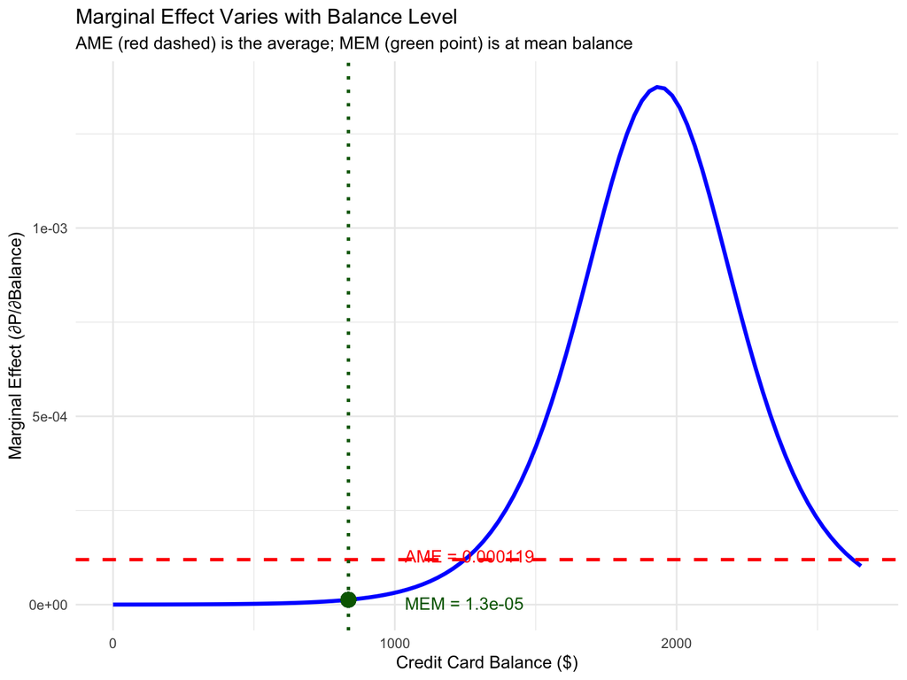

```r
# Create visualization comparing AME and MEM
balance_range <- seq(min(Default$balance), max(Default$balance), length.out = 100)
prob_range <- predict(logit_model,
                      newdata = data.frame(balance = balance_range),
                      type = "response")
me_range <- logit_coef[2] * prob_range * (1 - prob_range)

me_viz <- data.frame(
  balance = balance_range,
  probability = prob_range,
  marginal_effect = me_range
)

ggplot(me_viz, aes(x = balance, y = marginal_effect)) +
  geom_line(color = "blue", size = 1.2) +
  geom_hline(yintercept = ame, color = "red", linetype = "dashed", size = 1) +
  geom_vline(xintercept = mean_balance, color = "darkgreen", linetype = "dotted", size = 1) +
  geom_point(aes(x = mean_balance, y = mem), color = "darkgreen", size = 4) +
  annotate("text", x = mean_balance + 200, y = ame + 0.00001,
           label = paste0("AME = ", round(ame, 6)), color = "red", hjust = 0) +
  annotate("text", x = mean_balance + 200, y = mem - 0.00001,
           label = paste0("MEM = ", round(mem, 6)), color = "darkgreen", hjust = 0) +
  labs(title = "Marginal Effect Varies with Balance Level",
       subtitle = "AME (red dashed) is the average; MEM (green point) is at mean balance",
       x = "Credit Card Balance ($)",
       y = "Marginal Effect (∂P/∂Balance)") +
  theme_minimal()
```

**Key Insights**:

1. **AME** = 1.19^{-4}: On average across all customers, a $1 increase in balance increases default probability by 0.0119%
2. **MEM** = 1.3^{-5}: For a customer with the average balance ($835.37), a $1 increase increases default probability by 0.0013%
3. **Why MEM < AME**: The mean balance corresponds to a low default probability (only 0.23%), where the marginal effect is small. AME includes observations with higher probabilities where marginal effects are larger.
4. **Practical interpretation**: Most analysts report AME because it represents the average treatment effect across the population, which is more policy-relevant than the effect at one specific point.

### 3.4.5 Odds Ratio Interpretation

```r
# Calculate odds ratio for a $100 increase in balance
odds_ratio_100 <- exp(logit_coef[2] * 100)

# Create interpretation table
or_table <- data.frame(
  Balance_Increase = c(1, 100, 500),
  Odds_Ratio = exp(logit_coef[2] * c(1, 100, 500))
)

kable(or_table,
      caption = "Odds Ratios for Different Balance Increases",
      digits = 3,
      col.names = c("Balance Increase ($)", "Odds Ratio")) %>%
  kable_styling(bootstrap_options = c("striped", "hover"), full_width = FALSE)
```

Odds Ratios for Different Balance Increases

| Balance Increase ($) | Odds Ratio |
| --- | --- |
| 1 | 1.006 |
| 100 | 1.733 |
| 500 | 15.634 |

For a \$100 increase in balance, the odds of default multiply by 1.73. For a \$500 increase, the odds multiply by 15.63.

### 3.4.6 Multiple Predictors Example

```r
# Fit logistic model with multiple predictors
logit_full <- glm(default_binary ~ balance + income + student_binary,
                  data = Default, family = binomial)

summary(logit_full)
```

```
Call:
glm(formula = default_binary ~ balance + income + student_binary,
    family = binomial, data = Default)

Coefficients:
                 Estimate Std. Error z value Pr(>|z|)
(Intercept)    -1.087e+01  4.923e-01 -22.080  < 2e-16 ***
balance         5.737e-03  2.319e-04  24.738  < 2e-16 ***
income          3.033e-06  8.203e-06   0.370  0.71152
student_binary -6.468e-01  2.363e-01  -2.738  0.00619 **
---
Signif. codes:  0 '***' 0.001 '**' 0.01 '*' 0.05 '.' 0.1 ' ' 1

(Dispersion parameter for binomial family taken to be 1)

    Null deviance: 2920.6  on 9999  degrees of freedom
Residual deviance: 1571.5  on 9996  degrees of freedom
AIC: 1579.5

Number of Fisher Scoring iterations: 8
```

```r
# Calculate marginal effects for all variables
Default$fitted_prob_full <- predict(logit_full, type = "response")

# Marginal effects
me_balance <- mean(logit_full$coefficients[2] * Default$fitted_prob_full *
                    (1 - Default$fitted_prob_full))
me_income <- mean(logit_full$coefficients[3] * Default$fitted_prob_full *
                   (1 - Default$fitted_prob_full))
me_student <- mean(logit_full$coefficients[4] * Default$fitted_prob_full *
                    (1 - Default$fitted_prob_full))

# Summary of marginal effects
me_full <- data.frame(
  Variable = c("Balance", "Income", "Student"),
  Coefficient = coef(logit_full)[2:4],
  Odds_Ratio = exp(coef(logit_full)[2:4]),
  Avg_Marginal_Effect = c(me_balance, me_income, me_student)
)

kable(me_full,
      caption = "Full Model: Coefficients, Odds Ratios, and Marginal Effects",
      digits = 6) %>%
  kable_styling(bootstrap_options = c("striped", "hover"))
```

Full Model: Coefficients, Odds Ratios, and Marginal Effects

|  | Variable | Coefficient | Odds_Ratio | Avg_Marginal_Effect |
| --- | --- | --- | --- | --- |
| balance | Balance | 0.005737 | 1.005753 | 0.000123 |
| income | Income | 0.000003 | 1.000003 | 0.000000 |
| student_binary | Student | -0.646776 | 0.523732 | -0.013894 |

### 3.4.7 Model Comparison and Diagnostics

```r
# Compare predictions
pred_comparison <- data.frame(
  Actual = Default$default_binary,
  LPM = predict(lpm_model),
  Logistic = predict(logit_model, type = "response")
)

# Calculate correlation with actual outcomes
cor_lpm <- cor(pred_comparison$Actual, pred_comparison$LPM)
cor_logistic <- cor(pred_comparison$Actual, pred_comparison$Logistic)

# Root Mean Squared Error
rmse_lpm <- sqrt(mean((pred_comparison$Actual - pred_comparison$LPM)^2))
rmse_logistic <- sqrt(mean((pred_comparison$Actual - pred_comparison$Logistic)^2))

# Create comparison table
performance_table <- data.frame(
  Model = c("LPM", "Logistic"),
  Correlation = c(cor_lpm, cor_logistic),
  RMSE = c(rmse_lpm, rmse_logistic)
)

kable(performance_table,
      caption = "Model Performance Comparison",
      digits = 4,
      col.names = c("Model", "Correlation with Actual", "RMSE")) %>%
  kable_styling(bootstrap_options = c("striped", "hover"), full_width = FALSE)
```

Model Performance Comparison

| Model | Correlation with Actual | RMSE |
| --- | --- | --- |
| LPM | 0.3501 | 0.1681 |
| Logistic | 0.5707 | 0.1473 |

1. Predictions always fall in [0,1]
2. More realistic at extreme values
3. Better theoretical foundation for binary outcomes

### 3.4.8 Visualizing Marginal Effects

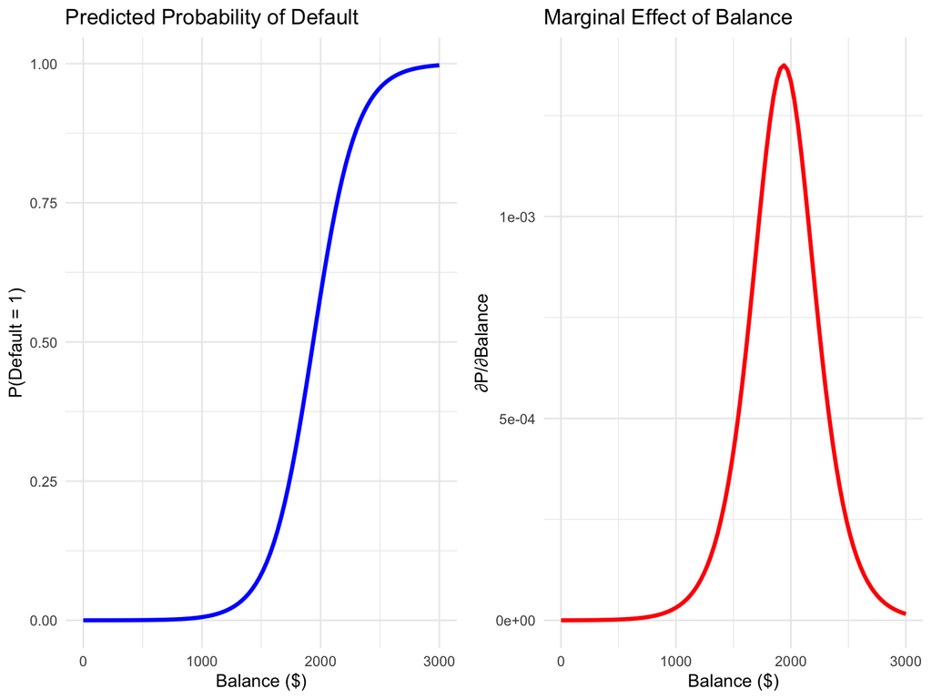

```r
# Create a grid of balance values
balance_seq <- seq(0, 3000, length.out = 100)

# Calculate probability and marginal effect at each point
me_data <- data.frame(
  balance = balance_seq,
  probability = predict(logit_model,
                       newdata = data.frame(balance = balance_seq),
                       type = "response")
)

me_data$marginal_effect <- logit_coef[2] * me_data$probability *
                           (1 - me_data$probability)

# Create two plots
p1 <- ggplot(me_data, aes(x = balance, y = probability)) +
  geom_line(color = "blue", size = 1.2) +
  labs(title = "Predicted Probability of Default",
       x = "Balance ($)",
       y = "P(Default = 1)") +
  theme_minimal()

p2 <- ggplot(me_data, aes(x = balance, y = marginal_effect)) +
  geom_line(color = "red", size = 1.2) +
  labs(title = "Marginal Effect of Balance",
       x = "Balance ($)",
       y = "∂P/∂Balance") +
  theme_minimal()

gridExtra::grid.arrange(p1, p2, ncol = 2)
```

The marginal effect is highest where the probability is around 0.5 and decreases at the extremes. This demonstrates why logistic regression coefficients cannot be interpreted as constant marginal effects.

## 3.5 Classification and Model Evaluation

So far, we’ve focused on estimating probabilities. But often, we need to make **binary classifications**: Is this customer likely to default or not? Will this patient respond to treatment or not?

To classify, we need to convert probabilities into binary predictions using a **threshold** (or cutoff). Understanding classification performance is crucial for practical applications.

### 3.5.1 Classification Threshold

Given a predicted probability $\hat{p}_i = P(Y_i=1|X_i)$, we classify:

$$\hat{Y}_i = \begin{cases}
1 & \text{if } \hat{p}_i \geq \text{threshold} \\
0 & \text{if } \hat{p}_i < \text{threshold}
\end{cases}$$

The **default threshold is 0.5**, but this isn’t always optimal. The choice depends on: - The cost of false positives vs false negatives - The base rate of the outcome - Business/policy objectives

### 3.5.2 Confusion Matrix

A **confusion matrix** summarizes classification performance:

|  | **Actual: Default** | **Actual: No Default** |
| --- | --- | --- |
| **Predicted: Default** | True Positive (TP) | False Positive (FP) |
| **Predicted: No Default** | False Negative (FN) | True Negative (TN) |

**Definitions**:

- **True Positive (TP)**: Correctly predicted default
- **True Negative (TN)**: Correctly predicted no default
- **False Positive (FP)**: Predicted default, but didn’t default (Type I error)
- **False Negative (FN)**: Predicted no default, but did default (Type II error)

### 3.5.3 Classification Metrics

From the confusion matrix, we calculate:

**1. Accuracy**: Overall correctness
$$\text{Accuracy} = \frac{TP + TN}{TP + TN + FP + FN}$$

**2. Precision** (Positive Predictive Value): When we predict default, how often are we right?
$$\text{Precision} = \frac{TP}{TP + FP}$$

**3. Recall** (Sensitivity, True Positive Rate): Of all actual defaults, what proportion do we catch?
$$\text{Recall} = \frac{TP}{TP + FN}$$

**4. Specificity** (True Negative Rate): Of all non-defaults, what proportion do we correctly identify?
$$\text{Specificity} = \frac{TN}{TN + FP}$$

**5. F1-Score**: Harmonic mean of precision and recall
$$\text{F1} = 2 \times \frac{\text{Precision} \times \text{Recall}}{\text{Precision} + \text{Recall}}$$

#### 3.5.3.1 Understanding the Harmonic Mean in F1-Score

The F1-Score uses the **harmonic mean** rather than the simple arithmetic mean. The harmonic mean has a special mathematical property that makes it ideal for evaluating classification models:

$$\text{Harmonic Mean}(a, b) = \frac{2ab}{a + b}$$

**Key Property: The harmonic mean is dominated by the smaller number.**

If either precision or recall is low, the harmonic mean becomes low. This prevents models from “gaming” the metric by optimizing only one measure.

**Example 1: Extreme Imbalance**

- Precision = 1.0 (perfect)
- Recall = 0.0 (catches nothing)
- **Arithmetic mean** = $(1.0 + 0.0)/2 = 0.5$ (misleadingly suggests 50% performance!)
- **F1-Score (harmonic mean)** = $\frac{2 \times 1.0 \times 0.0}{1.0 + 0.0} = 0.0$ ✓ (correctly punishes the model)

**Example 2: Moderate Imbalance**

- Precision = 0.9 (excellent)
- Recall = 0.1 (poor - misses 90% of positives)
- **Arithmetic mean** = $(0.9 + 0.1)/2 = 0.5$ (suggests decent performance)
- **F1-Score (harmonic mean)** = $\frac{2 \times 0.9 \times 0.1}{0.9 + 0.1} = 0.18$ ✓ (reflects true weakness)

**Why This Matters:**

The F1-Score becomes high **only if both precision AND recall are high**. This “harmonic balance” ensures that:

- A model cannot achieve a good F1 by excelling at one metric while ignoring the other
- The metric reflects the true ability to correctly identify positive cases (recall) while maintaining accuracy in those predictions (precision)
- It’s more stringent than arithmetic mean, providing a realistic assessment of model performance on the positive class

### 3.5.4 Applying to Our Default Example

Let’s evaluate our logistic regression model’s classification performance:

```r
# Use 0.5 threshold to classify
Default$predicted_class_05 <- ifelse(Default$fitted_prob > 0.5, 1, 0)

# Create confusion matrix - convert to factors with "1" first so TP appears at [1,1]
confusion_05 <- table(Predicted = factor(Default$predicted_class_05, levels = c("1", "0")),
                      Actual = factor(Default$default_binary, levels = c("1", "0")))

# Display confusion matrix
kable(confusion_05,
      caption = "Confusion Matrix (Threshold = 0.5)") %>%
  kable_styling(bootstrap_options = c("striped", "hover"), full_width = FALSE)
```

Confusion Matrix (Threshold = 0.5)

|  | 1 | 0 |
| --- | --- | --- |
| 1 | 100 | 42 |
| 0 | 233 | 9625 |

```r
# Calculate metrics - updated for new orientation: TP at [1,1]
TP <- confusion_05[1, 1]
TN <- confusion_05[2, 2]
FP <- confusion_05[1, 2]
FN <- confusion_05[2, 1]

accuracy <- (TP + TN) / sum(confusion_05)
precision <- TP / (TP + FP)
recall <- TP / (TP + FN)
specificity <- TN / (TN + FP)
f1_score <- 2 * (precision * recall) / (precision + recall)

# Create metrics table
metrics_05 <- data.frame(
  Metric = c("Accuracy", "Precision", "Recall (Sensitivity)",
             "Specificity", "F1-Score"),
  Value = round(c(accuracy, precision, recall, specificity, f1_score), 4),
  Interpretation = c(
    paste0(round(accuracy*100, 1), "% of predictions are correct"),
    paste0(round(precision*100, 1), "% of predicted defaults are actual defaults"),
    paste0(round(recall*100, 1), "% of actual defaults are caught"),
    paste0(round(specificity*100, 1), "% of non-defaults are correctly identified"),
    "Balance between precision and recall"
  )
)

kable(metrics_05,
      caption = "Classification Metrics (Threshold = 0.5)",
      col.names = c("Metric", "Value", "Interpretation")) %>%
  kable_styling(bootstrap_options = c("striped", "hover"))
```

Classification Metrics (Threshold = 0.5)

| Metric | Value | Interpretation |
| --- | --- | --- |
| Accuracy | 0.9725 | 97.2% of predictions are correct |
| Precision | 0.7042 | 70.4% of predicted defaults are actual defaults |
| Recall (Sensitivity) | 0.3003 | 30% of actual defaults are caught |
| Specificity | 0.9957 | 99.6% of non-defaults are correctly identified |
| F1-Score | 0.4211 | Balance between precision and recall |

### 3.5.5 Threshold Selection: Trade-offs

The 0.5 threshold isn’t always optimal. Let’s explore different thresholds:

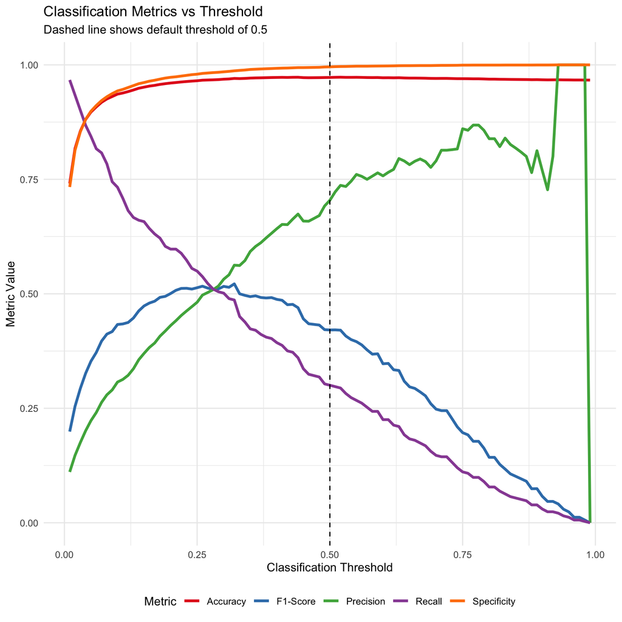

```r
# Function to calculate metrics for any threshold
calc_metrics <- function(actual, predicted_prob, threshold) {
  predicted_class <- ifelse(predicted_prob > threshold, 1, 0)
  cm <- table(Predicted = factor(predicted_class, levels = c("1", "0")),
              Actual = factor(actual, levels = c("1", "0")))

  # Handle cases where confusion matrix isn't 2x2
  # Initialize all counts to 0
  TP <- 0
  TN <- 0
  FP <- 0
  FN <- 0

  # Fill in values that exist in the confusion matrix - updated for new orientation
  # TP at [1,1], FP at [1,2], FN at [2,1], TN at [2,2]
  if ("1" %in% rownames(cm) && "1" %in% colnames(cm)) TP <- cm["1", "1"]
  if ("1" %in% rownames(cm) && "0" %in% colnames(cm)) FP <- cm["1", "0"]
  if ("0" %in% rownames(cm) && "1" %in% colnames(cm)) FN <- cm["0", "1"]
  if ("0" %in% rownames(cm) && "0" %in% colnames(cm)) TN <- cm["0", "0"]

  accuracy <- (TP + TN) / sum(cm)
  # Handle division by zero
  precision <- ifelse((TP + FP) > 0, TP / (TP + FP), 0)
  recall <- ifelse((TP + FN) > 0, TP / (TP + FN), 0)
  specificity <- ifelse((TN + FP) > 0, TN / (TN + FP), 0)
  f1 <- ifelse((precision + recall) > 0,
               2 * (precision * recall) / (precision + recall), 0)

  return(data.frame(
    threshold = threshold,
    accuracy = accuracy,
    precision = precision,
    recall = recall,
    specificity = specificity,
    f1_score = f1
  ))
}

# Calculate metrics for various thresholds
thresholds <- seq(0.01, 0.99, by = 0.01)
metrics_df <- do.call(rbind, lapply(thresholds, function(t) {
  calc_metrics(Default$default_binary, Default$fitted_prob, t)
}))

# Plot metrics across thresholds
metrics_long <- metrics_df %>%
  pivot_longer(cols = c(accuracy, precision, recall, specificity, f1_score),
               names_to = "metric", values_to = "value")

ggplot(metrics_long, aes(x = threshold, y = value, color = metric)) +
  geom_line(size = 1.2) +
  geom_vline(xintercept = 0.5, linetype = "dashed", color = "black") +
  labs(title = "Classification Metrics vs Threshold",
       subtitle = "Dashed line shows default threshold of 0.5",
       x = "Classification Threshold",
       y = "Metric Value",
       color = "Metric") +
  scale_color_brewer(palette = "Set1",
                     labels = c("Accuracy", "F1-Score", "Precision",
                                "Recall", "Specificity")) +
  theme_minimal() +
  theme(legend.position = "bottom")
```

**Key Insights**:

1. **Recall decreases** as threshold increases (we catch fewer defaults)
2. **Precision increases** as threshold increases (fewer false alarms)
3. **Trade-off**: Higher threshold = fewer false positives but more false negatives
4. **F1-Score** balances precision and recall

### 3.5.6 Finding the Optimal Threshold

The “optimal” threshold depends on your objective. Common approaches:

**1. Maximize F1-Score** (balance precision and recall)

```r
# Find threshold that maximizes F1
optimal_f1_idx <- which.max(metrics_df$f1_score)
optimal_f1_threshold <- metrics_df$threshold[optimal_f1_idx]
optimal_f1_value <- metrics_df$f1_score[optimal_f1_idx]

# Calculate confusion matrix at optimal threshold
Default$predicted_optimal <- ifelse(Default$fitted_prob > optimal_f1_threshold, 1, 0)
confusion_optimal <- table(Predicted = factor(Default$predicted_optimal, levels = c("1", "0")),
                           Actual = factor(Default$default_binary, levels = c("1", "0")))

kable(confusion_optimal,
      caption = paste0("Confusion Matrix (Optimal Threshold = ",
                       round(optimal_f1_threshold, 3), ")")) %>%
  kable_styling(bootstrap_options = c("striped", "hover"), full_width = FALSE)
```

Confusion Matrix (Optimal Threshold = 0.32)

|  | 1 | 0 |
| --- | --- | --- |
| 1 | 162 | 126 |
| 0 | 171 | 9541 |

The optimal threshold for F1-score is **0.32**, which gives F1 = 0.5217.

**2. Balance Sensitivity and Specificity** (where curves intersect)

Another approach is to find the threshold where **sensitivity (recall) equals specificity**—the point where the two curves intersect. This represents a balanced trade-off between two competing objectives:

- **Sensitivity (Recall)**: How well we identify actual positives (defaults)
- **Specificity**: How well we identify actual negatives (non-defaults)

**What Does the Intersection Mean?**

At the intersection point, the model performs equally well at: - Catching actual defaults (True Positive Rate = Sensitivity) - Correctly identifying non-defaults (True Negative Rate = Specificity)

This threshold represents **equal treatment of both classes** rather than focusing primarily on the positive class (as F1 does).

**When to Use This Approach:**

This balanced threshold is appropriate when:

1. **Equal error costs**: False positives and false negatives have similar consequences
2. **Fairness considerations**: You want to treat both classes (default/non-default) equally
3. **No class preference**: Neither class is inherently more important
4. **Symmetric decision-making**: Equal concern for Type I and Type II errors

**Comparison with F1-Score Optimization:**

| Criterion | F1-Score | Sensitivity-Specificity Balance |
| --- | --- | --- |
| **Focus** | Positive class only (Precision + Recall) | Both classes equally (TP rate + TN rate) |
| **When to use** | Imbalanced data, care most about minority class | Balanced importance of both classes |
| **Interpretation** | How well we handle positives | How balanced our errors are across classes |
| **Typical threshold** | Often < 0.5 for rare events | Closer to 0.5 for balanced problems |

Let’s visualize this balance:

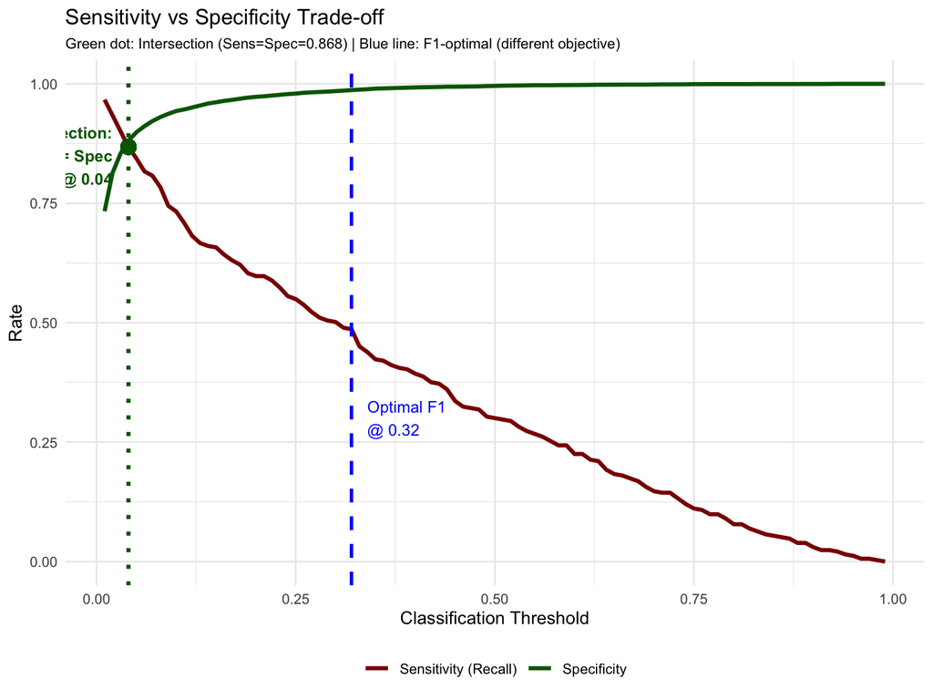

```r
# Find the intersection point where Sensitivity = Specificity
# This minimizes abs(recall - specificity)
metrics_df$diff <- abs(metrics_df$recall - metrics_df$specificity)
intersection_idx <- which.min(metrics_df$diff)
intersection_threshold <- metrics_df$threshold[intersection_idx]
intersection_value <- metrics_df$recall[intersection_idx]

# Plot sensitivity vs specificity
ggplot(metrics_df, aes(x = threshold)) +
  geom_line(aes(y = recall, color = "Sensitivity (Recall)"), size = 1.2) +
  geom_line(aes(y = specificity, color = "Specificity"), size = 1.2) +
  # Add intersection point (where Sensitivity = Specificity)
  geom_vline(xintercept = intersection_threshold, linetype = "dotted",
             color = "darkgreen", size = 1.2) +
  geom_point(x = intersection_threshold, y = intersection_value,
             color = "darkgreen", size = 4) +
  # Add F1 optimal for comparison
  geom_vline(xintercept = optimal_f1_threshold, linetype = "dashed",
             color = "blue", size = 1) +
  annotate("text", x = intersection_threshold - 0.02, y = 0.85,
           label = paste0("Intersection:\nSens = Spec\n@ ", round(intersection_threshold, 3)),
           hjust = 1, color = "darkgreen", fontface = "bold", size = 3.5) +
  annotate("text", x = optimal_f1_threshold + 0.02, y = 0.3,
           label = paste0("Optimal F1\n@ ", round(optimal_f1_threshold, 3)),
           hjust = 0, color = "blue", size = 3.5) +
  labs(title = "Sensitivity vs Specificity Trade-off",
       subtitle = paste0("Green dot: Intersection (Sens=Spec=", round(intersection_value, 3),
                        ") | Blue line: F1-optimal (different objective)"),
       x = "Classification Threshold",
       y = "Rate",
       color = NULL) +
  scale_color_manual(values = c("Sensitivity (Recall)" = "darkred",
                                 "Specificity" = "darkgreen")) +
  theme_minimal() +
  theme(legend.position = "bottom",
        plot.subtitle = element_text(size = 9))
```

**Key Insight:** The intersection occurs at threshold ≈ 0.04, where both Sensitivity and Specificity equal approximately 0.868. This is found by **minimizing** the absolute difference `|Sensitivity - Specificity|`. The F1-optimal threshold (≈0.32) is different because it optimizes a different objective (harmonic mean of precision and recall).

### 3.5.7 Decision Framework: Which Threshold Criterion to Use?

Both approaches give different thresholds because they optimize **different objectives**. Here’s how to choose:

#### 3.5.7.1 Understanding the Fundamental Difference

Threshold Selection Criteria: F1-Score vs Sensitivity-Specificity Balance

| Criterion | What It Optimizes | Focus | Metrics Balanced | Best For | What It Ignores | Typical Threshold | Example Use Cases |
| --- | --- | --- | --- | --- | --- | --- | --- |
| Max F1-Score | Harmonic mean of Precision & Recall | Positive class only | Precision + Recall (both about positives) | Imbalanced data, minority class matters most | How well we identify negatives (Specificity) | Often << 0.5 for rare events | Fraud detection, disease screening, rare events |
| Min abs(Sens - Spec) | Equal Sensitivity & Specificity | Both classes equally | True Positive Rate + True Negative Rate | Balanced importance of both classes | Neither - treats both equally | Closer to 0.5 for balanced problems | Hiring fairness, balanced loan decisions |

#### 3.5.7.2 When to Use Each Approach

**Use MAX F1-SCORE when:**

1. **Imbalanced data** (e.g., 1% positive class, 99% negative)
   - Example: Credit card fraud (rare frauds among millions of transactions)
   - Why: F1 focuses on the minority class you care about
2. **Positive class is critical**
   - Example: Disease diagnosis - missing a sick patient (FN) is costly
   - Why: F1 ensures you catch positives while maintaining precision
3. **Asymmetric interest** - you primarily care about one outcome
   - Example: Spam detection - focus on catching spam (positive class)
   - Why: Specificity (correctly identifying non-spam) is less critical
4. **Evaluation focuses on minority class performance**
   - Example: Rare event prediction, anomaly detection
   - Why: Accuracy would be misleadingly high (99% by predicting all negative)

**Use MIN |SENSITIVITY - SPECIFICITY| when:**

1. **Both classes are equally important**
   - Example: Medical test where both false alarms AND missed cases matter
   - Why: Want equal performance on detecting disease AND ruling it out
2. **Fairness considerations**
   - Example: Hiring decisions (must be fair to both hired/not hired candidates)
   - Why: Regulatory requirements for equal error rates
3. **Balanced costs** - false positives and false negatives cost similarly
   - Example: Resource allocation where over-allocation and under-allocation are equally problematic
   - Why: Symmetric loss function
4. **Symmetric decision-making**
   - Example: Quality control where accepting bad items = rejecting good items in cost
   - Why: No inherent preference for one type of error

#### 3.5.7.3 Real-World Examples with Recommendations

Threshold Selection: Real-World Decision Guide

| Scenario | Class Balance | Primary Concern | Recommended Criterion | Reasoning |
| --- | --- | --- | --- | --- |
| Cancer Screening | 1-5% positive | Missing cancer (FN) | Max F1 | Rare disease, catch cases even with some false alarms |
| Credit Card Fraud | 0.1% positive | Missing fraud (FN) | Max F1 | Extremely rare, must catch fraud despite false positives |
| Loan Default Prediction | 3% positive | Loan defaults (FN) | Cost-based (likely low threshold) | Defaults costly but false rejections lose customers |
| Spam Email Filter | 10-30% spam | Catching spam (FN) | Max F1 | Imbalanced, focus on catching spam |
| Job Applicant Screening | ~50% hired | Fair to both groups | Min bas(Sens-Spec) | Legal fairness requirements, balanced classes |
| COVID-19 Testing | Varies by outbreak | Missing cases (FN) early; both later | Max F1 initially; Min abs(S-S) later | Early: catch cases. Later: test accuracy for both |
| Customer Churn | 10-20% churn | Identifying churners | Max F1 | Imbalanced, retain customers who might churn |
| A/B Test Winner Selection | ~50-50 | Fair comparison | Min abs(Sens-Spec) | No preference for either variant, fair evaluation |

#### 3.5.7.4 The Class Imbalance Factor

For our credit card default example:

- **Actual default rate**: 3.3% (highly imbalanced!)
- **F1-optimal threshold**: 0.32 (prioritizes catching the rare defaults)
- **Intersection threshold**: 0.04 (treats both classes equally)

**Why such a difference?**

With only 3.3% defaults, the intersection point occurs at a very low threshold where we’re casting a wide net to achieve balance. The F1-optimal threshold is higher because it focuses specifically on the performance on defaults (the minority class we care about), accepting that we’ll have high specificity regardless.

**Rule of Thumb:**

- **Class imbalance < 20%**: Strongly consider Max F1 (unless fairness mandates otherwise)
- **Class imbalance 40-60%**: Min |Sens-Spec| often appropriate
- **Always**: Consider business costs! Cost-based optimization (see next section) often dominates

### 3.5.8 Business Context Matters

The optimal threshold depends on the **costs of errors**:

**Example 1: Loan Default Prediction**

- **False Negative** (miss a default): Lose the entire loan amount
- **False Positive** (reject good customer): Lose potential interest income
- If loss from FN >> loss from FP → Use **lower threshold** (catch more defaults)

**Example 2: Medical Screening**

- **False Negative** (miss a disease): Patient doesn’t get treatment
- **False Positive** (false alarm): Unnecessary follow-up tests
- If FN is life-threatening → Use **lower threshold** (higher sensitivity)

```r
# Suppose: Cost of FN = $10,000, Cost of FP = $100
cost_fn <- 10000
cost_fp <- 100

# Calculate expected cost for each threshold
metrics_df <- metrics_df %>%
  mutate(
    total_defaults = sum(Default$default_binary),
    total_non_defaults = sum(1 - Default$default_binary),
    fn_count = total_defaults * (1 - recall),
    fp_count = total_non_defaults * (1 - specificity),
    expected_cost = fn_count * cost_fn + fp_count * cost_fp
  )

# Find cost-minimizing threshold
optimal_cost_idx <- which.min(metrics_df$expected_cost)
optimal_cost_threshold <- metrics_df$threshold[optimal_cost_idx]
optimal_cost <- metrics_df$expected_cost[optimal_cost_idx]

# Display optimal thresholds summary
threshold_summary <- data.frame(
  Objective = c("Default (0.5)", "Maximize F1-Score",
                "Minimize Expected Cost (FN=$10K, FP=$100)"),
  Threshold = c(0.5, optimal_f1_threshold, optimal_cost_threshold),
  F1_Score = c(
    metrics_df$f1_score[metrics_df$threshold == 0.5],
    optimal_f1_value,
    metrics_df$f1_score[optimal_cost_idx]
  ),
  Expected_Cost = c(
    metrics_df$expected_cost[metrics_df$threshold == 0.5],
    metrics_df$expected_cost[optimal_f1_idx],
    optimal_cost
  )
)

kable(threshold_summary,
      caption = "Threshold Selection Based on Different Objectives",
      digits = c(0, 3, 4, 0),
      col.names = c("Objective", "Threshold", "F1-Score", "Expected Cost ($)")) %>%
  kable_styling(bootstrap_options = c("striped", "hover"))
```

Threshold Selection Based on Different Objectives

| Objective | Threshold | F1-Score | Expected Cost ($) |
| --- | --- | --- | --- |
| Default (0.5) | 0.50 | 0.4211 | 2334200 |
| Maximize F1-Score | 0.32 | 0.5217 | 1722600 |
| Minimize Expected Cost (FN=$10K, FP=$100) | 0.01 | 0.1991 | 367900 |

**Key Takeaway**: When costs are asymmetric, the optimal threshold shifts. Here, since false negatives are much more costly, the optimal threshold (0.01) is lower than 0.5, prioritizing sensitivity over specificity.

## 3.6 When to Use LPM vs Logistic

### 3.6.2 Use Logistic when:

1. **Theoretical correctness**: Standard for binary outcomes in most fields
2. **Extreme predictions**: When you need predictions near 0 or 1
3. **Odds ratios**: When you want to report odds ratios
4. **Publication**: Most journals expect logistic for binary outcomes
5. **Model comparison**: AIC, BIC, and likelihood ratio tests are available

# 4 Summary and Key Takeaways

## 4.1 Part 1: Dummy Variables

1. **Binary dummies**: Coefficient equals mean difference between groups
2. **Multiple categories**: Use k-1 dummies to avoid the dummy variable trap
3. **Interactions**:
   - Dummy × Continuous: Different slopes for different groups
   - Dummy × Dummy: Combined effects beyond simple addition
4. **Connection to t-tests**: Dummy variable regression is equivalent to two-sample t-test

## 4.2 Part 2: Probability Models

### 4.2.1 Linear Probability Model

**Pros**: - Simple interpretation: coefficients are marginal effects - Easy to estimate (OLS) - Good approximation in middle probability ranges

**Cons**: - Predictions can fall outside [0,1] - Heteroskedasticity (though often not severe) - Assumes constant marginal effects

### 4.2.2 Logistic Regression

**Pros**: - Predictions always in [0,1] - Theoretically appropriate for binary outcomes - S-shaped probability curve - Flexible interpretation (log-odds, odds ratios, marginal effects)

**Cons**: - More complex interpretation - Requires iterative estimation (MLE) - Marginal effects vary with X

### 4.2.3 Mathematical Foundations

We covered three key estimation approaches:

1. **OLS/LPM**: Minimize sum of squared residuals
2. **MLE**: Maximize likelihood of observing the data
3. **Interpretation**: Link between coefficients, odds ratios, and marginal effects

### 4.2.4 Practical Recommendations

1. Start with LPM for quick analysis and interpretation
2. Use logistic regression for final models and publication
3. Always report marginal effects (AME or MEM) for logistic models
4. Visualize predicted probabilities to aid interpretation
5. Consider model diagnostics and goodness-of-fit measures

# 5 Additional Resources

For further study:

- **Dummy variables**: Understanding interaction terms and their interpretation
- **Logistic regression**: Probit models as an alternative
- **Model diagnostics**: ROC curves, confusion matrices, classification metrics
- **Extensions**: Multinomial logit for outcomes with >2 categories
- **Panel data**: Fixed effects with dummy variables

**End of Lesson: Dummy Variables and Probability Models**